# Project 5 - Website Updates

Keyron

## Goals

- Fix Project 3 and 4
- Try to get a custom domain name!
- Clean up my about me section
- Make everything fit with a dark theme

## Buying a Domain

- Github pages allows us to use custom domain names!
- This requires us to purchase a custom domain, and to verify it through github
- I’ve begun the process of buying a domain, and spent some time researching how to verify it. However, as you can see, It hasn’t happened yet (more time and money needed)

[figure not shown]

## Fixing Project 3

For my original attempt at creating a null sampling distribution, I incorrectly shuffled the income between all public and private schools, instead of switching the public/private labels.

- I fixed this!
- Now it’s very obvious that the null hypothesis is FALSE
- Updated colors and added descriptive text to fit with dark theme

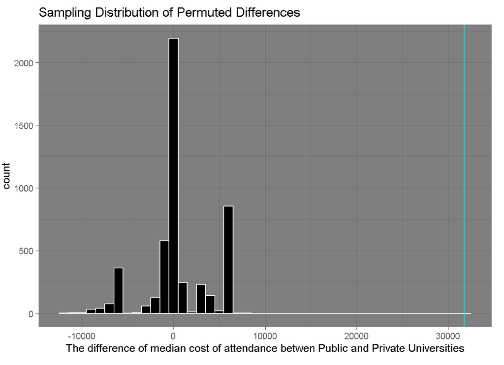

## Updating Project 4

- Added proper citations + added more descriptive comments
- Added more narrative! Made this much easier to read if you’re not coming from this class
- Fixed a bug caused by joining on identifier instead of SubjectNumber

## Tidy Tuesday!

- I’ve been to a few tidy tuesdays!
- These were super easy to pop onto my website
- Added this cool regex assignment to puff up the data science project

## Site clean-up and tweaks

- Added the correct links to my socials + headers
- Removed error messages
- Added images + Dark theme
- Consolidated all DS2R projects together

## To-Do

- Get that custom domain name!
- Add my coding projects: I want this to be a portfolio/project website for recruiters
- Add more flair + shiny stuff
- Thank you!